# Praca domowa 2

Piotr Wysocki

## Dane

Dane wykorzystane w Pracy domowej 2 opisują wycenę nieruchmości. Każda obserwacja jest pewną nieruchmością, która posiada informacje takie jak powierzchnia, liczba pokoi, liczba łazienek i wiele więcj. Opis wszystkich kolumn w pliku `README.md`.

## Zadanie 1

Jak wygląda rozkład ceny nieruchomości w poszczególnych kodach pocztowych na przestrzeni lat? Rozważamy kody pocztowe, które mają więcej niż 280 posiadłości.

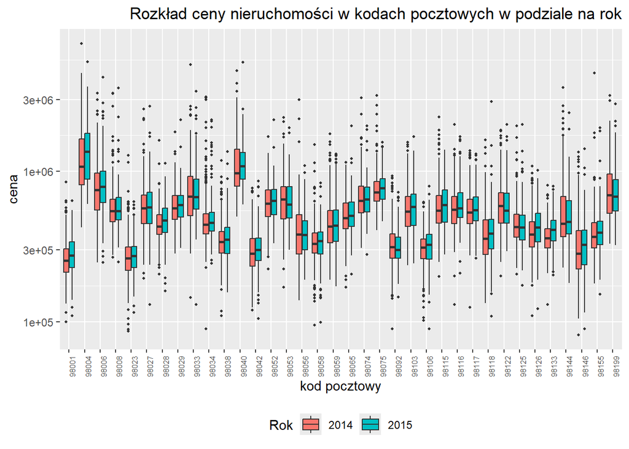

```r
df %>% group_by(zipcode) %>% filter(n()>280) %>%
  mutate(zipcode_group = paste0("Group ", (as.numeric(as.factor(zipcode)) - 1) %/% 6 + 1), Rok = substr(as.character(date),1,4)) %>% ggplot(aes(x=as.factor(zipcode),y = price, fill = Rok)) +
  geom_boxplot(outlier.size = 0.75) +
   scale_colour_discrete(name = "Rok") +
  scale_y_log10() +
  theme(axis.text.x = element_text(angle = 90, size = 6), legend.position = "bottom", plot.title = element_text(hjust = 1)) + labs(title = "Rozkład ceny nieruchomości w kodach pocztowych w podziale na rok", x = "kod pocztowy", y = "cena", color = "Rok")
```

**Komentarz:** Widzimy, że ceny na przestrzeni roku nie zmienily się znacząco. Widać tylko różnice między poszczególnymi kodami pocztowymi.

## Zadanie 2

Czy jest różnica w rozkładzie ceny nierchomości od powierzchni mieszkalnej uwzględniając podział na nieruchomości z piwnicą i bez?

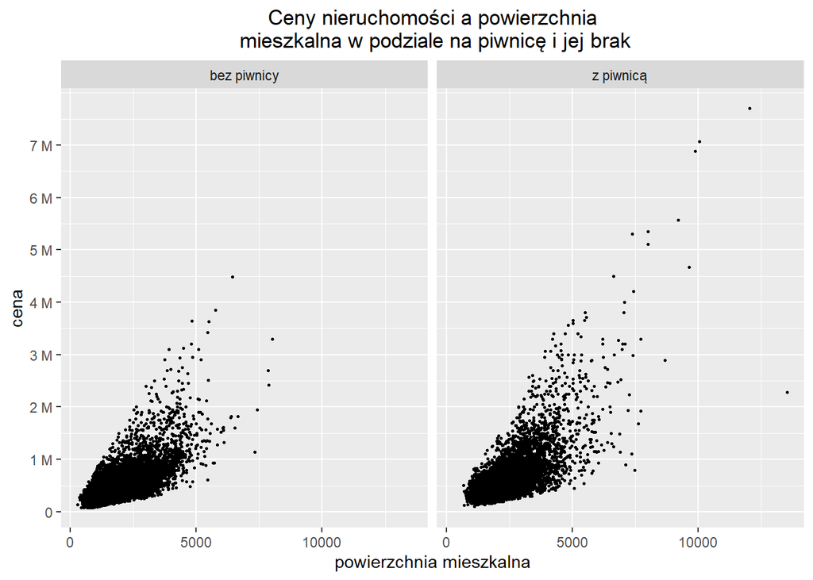

```r
df %>% mutate(piwnica = case_when(sqft_basement == 0 ~"bez piwnicy", sqft_basement > 0 ~"z piwnicą")) %>%
  ggplot(aes(x = sqft_living, y = price)) +
  geom_point(size = 0.5) +
 facet_wrap(~piwnica) + labs(title = "Ceny nieruchomości a powierzchnia\n mieszkalna w podziale na piwnicę i jej brak", x = "powierzchnia mieszkalna", y = "cena") + theme(plot.title = element_text(hjust = 0.5))+
  scale_y_continuous(breaks = seq(0,max(df$price),by = 1000000), labels = function(x) ifelse(x>0, paste(as.character(x/1e6),"M"),"0"))
```

Jaka jest zależność pomiędzy jakością wykończenia nieruchomości a liczbą pięter?

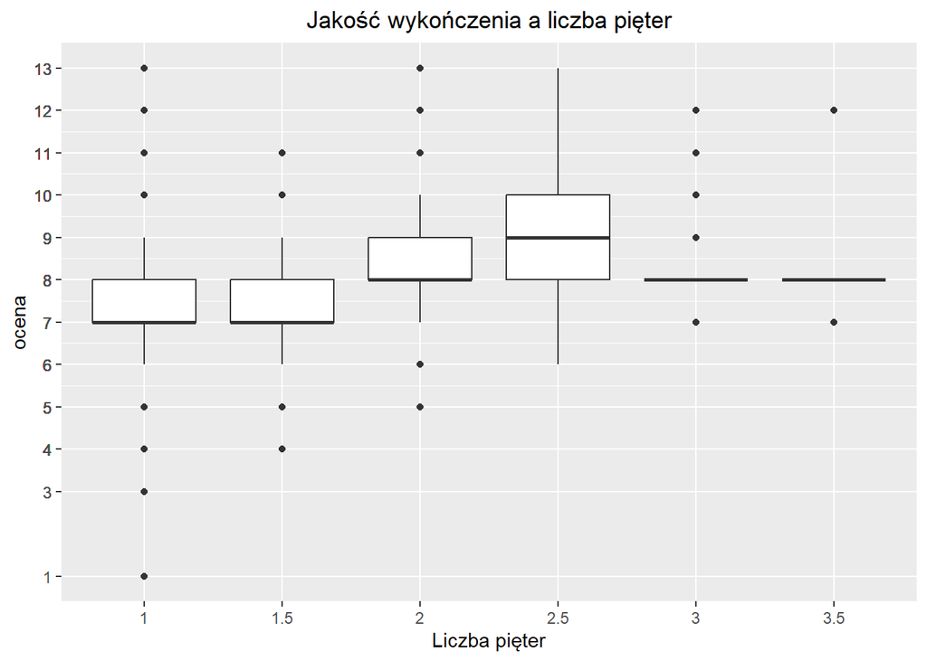

```r
df %>% ggplot(aes(x = factor(floors), y = grade))  +
  geom_boxplot() + labs(title = "Jakość wykończenia a liczba pięter", x = "Liczba pięter" , y = "ocena") + scale_y_continuous(breaks = df$grade) +
  theme(plot.title = element_text(hjust = 0.5))
```

**Komentarz:** Zależność jest rosnąca - im więcej pięter tym wyższa ocena. Dla 3 i 3.5 piętra zbyt mało danych, aby stwierdzić.

## Zadanie 4

Jaka jest zależność między powierzchnią mieszkalną nieruchomości a powierzchnią gruntu w podziale na liczbę sypialni?

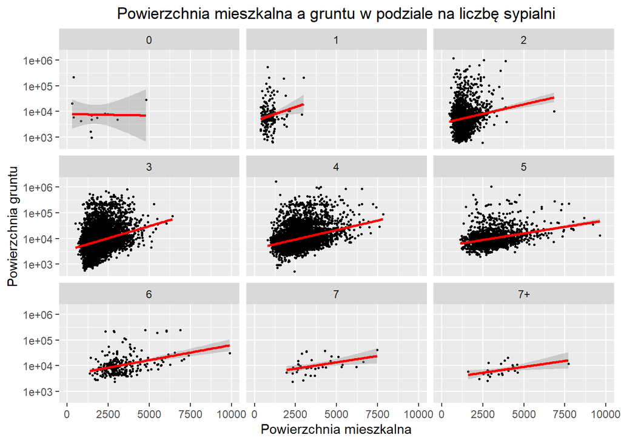

```r
df %>% mutate(bedrooms = case_when(bedrooms >7 ~"7+", .default = as.character(bedrooms))) %>% ggplot(aes(x = sqft_living, y = sqft_lot)) + geom_point(size = .5) + scale_y_log10() + geom_smooth(method = "lm", col = "red") + facet_wrap(~ bedrooms) + labs(title = "Powierzchnia mieszkalna a gruntu w podziale na liczbę sypialni", x = "Powierzchnia mieszkalna", y = "Powierzchnia gruntu") + scale_x_continuous(limits= c(0,10000)) + scale_y_log10() + theme(plot.title = element_text(hjust = 0.5))
```

**Komentarz:** Istnieje niska zależność między tymi wielkościami. W przypadku zera sypialni zależność nieznacznie odwrotna.

## Zadanie 5

Rozważmy tylko nieruchomości, które miały remont. W której dekadzie było najwięcej przeprowadzonych remontów? Czy w poszczególnych dekadach jest porównywalny procent nieruchmości dla każdej wartości miary jakości i wykończenia nieruchomości?

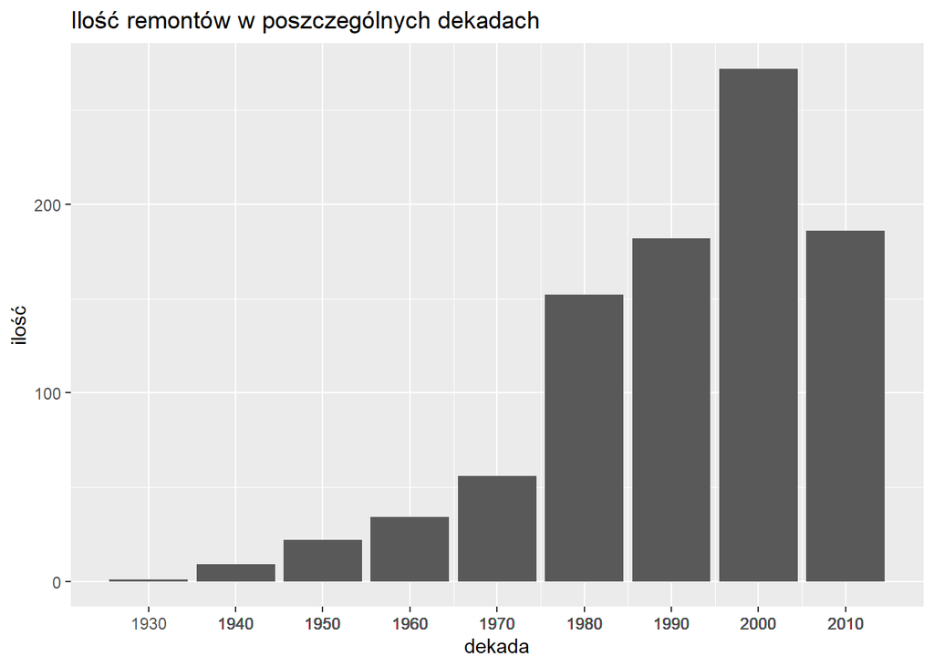

```r
df %>% filter(yr_renovated != 0) %>%
  mutate(yr_renovated = (yr_renovated %/%10)*10) %>%
  ggplot(aes(x = yr_renovated)) + scale_x_continuous(breaks = (df$yr_renovated %/%10)*10) +
  geom_bar() + labs(title = "Ilość remontów w poszczególnych dekadach",x = "dekada", y = "ilość")
```

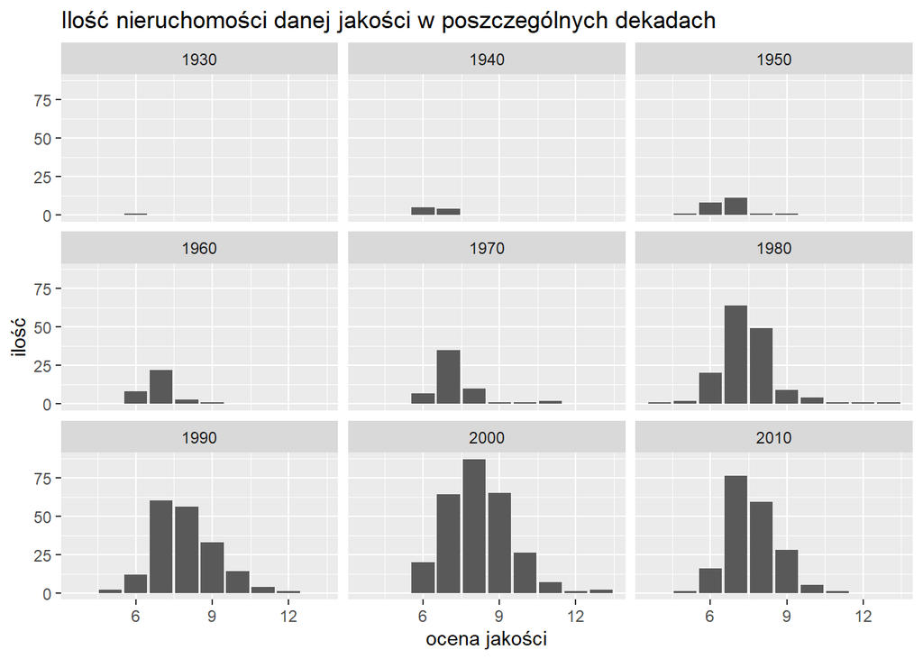

```r
df %>% filter(yr_renovated != 0) %>%
  mutate(yr_renovated = (yr_renovated %/%10)*10) %>%
  ggplot(aes(x = grade)) + geom_bar() +
  facet_wrap(~yr_renovated) + labs(title = "Ilość nieruchomości danej jakości w poszczególnych dekadach",x = "ocena jakości", y = "ilość")
```

**Komentarz:** Najwięcej remontów było w 2000. Te procenty nieruchomości w każdej mierze znacząco się różnią.

## Zadanie 6

Jak prezentuje się wartość minimalna, średnia i maksymalna ceny nieruchmości w podziele na rok budowy nieruchomości.

```r
library(tidyr)
```

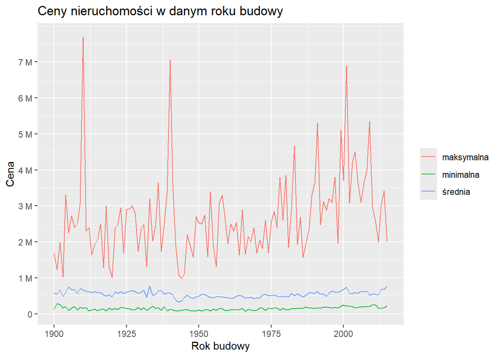

```r
df %>% group_by(yr_built) %>% summarise(minimalna = min(price), średnia = mean(price), maksymalna = max(price)) %>% pivot_longer(c(minimalna, średnia, maksymalna), names_to = "rodzaj", values_to = "cena") %>% ggplot(aes(x = yr_built, y = cena, color = rodzaj)) + geom_line() +
    theme(legend.title = element_blank()) + labs(title="Ceny nieruchomości w danym roku budowy", x = "Rok budowy", y = "Cena") +
  scale_y_continuous(breaks = seq(0,max(df$price),by = 1000000), labels = function(x) ifelse(x>0, paste(as.character(x/1e6),"M"),"0"))
```

**Komentarz:** Maksymalne wartości różniły się znacząco na przestrzeni lat, w przypadku cen średnich i minimalnych różnice były względnie niewielkie.